# Laboratorio 6

## Data Science

Javier Alejandro Ovalle Chiquín, 22103  
José Ángel Morales Farfán, 22689  
Ricardo Josué Morales Contreras, 22289  
Link del github: https://github.com/Saiyan-Javi/Lab6DS

```python
import pandas as pd
import json, re
import numpy as np
from scipy.sparse import coo_matrix, csr_matrix
import networkx as nx
import matplotlib.pyplot as plt
from networkx.algorithms.community import greedy_modularity_communities
from textblob import TextBlob
from sklearn.feature_extraction.text import CountVectorizer
from sklearn.decomposition import LatentDirichletAllocation
```

```python
# ---------- Lectura robusta ----------
def read_text_robust(path):
    for enc in ("utf-8-sig", "utf-16", "latin-1", "utf-8"):
        try:
            with open(path, "r", encoding=enc) as f:
                return f.read()
        except UnicodeDecodeError:
            continue
    with open(path, "rb") as f:
        return f.read().decode("utf-8", "ignore")

# ---------- Parser JSONL tolerante ----------
def parse_jsonl(content: str):
    recs = []
    for line in content.strip().splitlines():
        s = line.strip()
        if not s:
            continue
        # quitar coma final y quedarnos con {...}
        if s.endswith(","):
            s = s[:-1].rstrip()
        if "{" in s and "}" in s:
            s = s[s.find("{"): s.rfind("}") + 1]
        try:
            obj = json.loads(s)
            if isinstance(obj, dict):
                recs.append(obj)
        except Exception:
            # si una línea falla, la saltamos
            continue
    return recs

# ---------- Normalización a columnas ----------
def flatten_tweet(obj: dict) -> dict:
    user = obj.get("user") or {}
    if isinstance(user, dict):
        username    = user.get("username") or user.get("screen_name")
        displayname = user.get("displayname") or user.get("name")
    else:
        username, displayname = (None, None)

    # mentionedUsers puede venir como lista de dicts
    musers = []
    if isinstance(obj.get("mentionedUsers"), list):
        for m in obj["mentionedUsers"]:
            if isinstance(m, dict):
                u = m.get("username") or m.get("screen_name")
                if u: musers.append(u)

    # hashtags pueden venir como lista de strings
    hashtags = obj.get("hashtags") if isinstance(obj.get("hashtags"), list) else []

    # links pueden venir como lista de dicts con 'url'
    links = []
    if isinstance(obj.get("links"), list):
        for l in obj["links"]:
            if isinstance(l, dict):
                u = l.get("url") or l.get("expanded_url")
                if u: links.append(u)

    in_reply_to_user = None
    if isinstance(obj.get("inReplyToUser"), dict):
        in_reply_to_user = obj["inReplyToUser"].get("username") or obj["inReplyToUser"].get("screen_name")

    return {
        "tweet_id": str(obj.get("id") or obj.get("id_str") or ""),
        "url": obj.get("url"),
        "date": pd.to_datetime(obj.get("date"), utc=True, errors="coerce"),
        "username": username,
        "displayname": displayname,
        "text": obj.get("rawContent") or obj.get("full_text") or obj.get("text"),
        "reply_count": obj.get("replyCount") or obj.get("reply_count"),
        "retweet_count": obj.get("retweetCount") or obj.get("retweet_count"),
        "like_count": obj.get("likeCount") or obj.get("favorite_count"),
        "quote_count": obj.get("quoteCount") or obj.get("quote_count"),
        "mentioned_users": musers,
        "hashtags": hashtags,
        "links": links,
        "is_retweet": obj.get("retweetedTweet") is not None,
        "is_quote": obj.get("quotedTweet") is not None,
        "in_reply_to_user": in_reply_to_user,
        "lang": obj.get("lang"),
        "sourceLabel": obj.get("sourceLabel") or obj.get("source"),
    }

def load_tweets(path: str) -> pd.DataFrame:
    content = read_text_robust(path)
    recs = parse_jsonl(content)
    rows = [flatten_tweet(r) for r in recs]
    df = pd.DataFrame(rows)

    # columnas ordenadas
    order = ["tweet_id","date","username","displayname","text",
             "reply_count","retweet_count","like_count","quote_count",
             "is_retweet","is_quote","in_reply_to_user",
             "mentioned_users","hashtags","links","url","lang","sourceLabel"]
    df = df[[c for c in order if c in df.columns]].copy()

    # opcional: fecha local
    if "date" in df and pd.api.types.is_datetime64_any_dtype(df["date"]):
        try:
            df["date_local"] = df["date"].dt.tz_convert("America/Guatemala")
        except Exception:
            pass
    return df

# --------- Usa el loader con tus archivos ----------
df_trafico  = load_tweets("traficogt.txt")
# Si también tienes 'tioberny.txt', descomenta:
# df_tioberny = load_tweets("tioberny.txt")

print("traficogt:", df_trafico.shape)
print(df_trafico.head(5))
```

```
traficogt: (5604, 19)
              tweet_id                      date         username  \
0  1834236045598056867 2024-09-12 14:22:06+00:00        traficogt
1  1834029142565658846 2024-09-12 00:39:56+00:00     monymmorales
2  1834039491826180424 2024-09-12 01:21:04+00:00  animaldgalaccia
3  1833963729136091179 2024-09-11 20:20:01+00:00   EstacionDobleA
4  1833665391698092330 2024-09-11 00:34:31+00:00       CubReserva

                 displayname  \
0                  traficoGT
1                       Mony
2           Jairo De La Nada
3           Estación Doble A
4  CUB Reserva Kanajuyu Z 16

```

[output cut: 41 more lines]

#### 3) Limpieza de los datos

#### 3.1) Quitar caracteres especiales

```python
# --- Expresiones regulares ---
URL_RE      = re.compile(r"https?://\S+")
MENTION_RE  = re.compile(r"@\w{1,20}")
HASHTAG_RE  = re.compile(r"#\w+")
EMOJI_RE    = re.compile(
    "["
    "\U0001F300-\U0001F5FF"  # símbolos y pictogramas
    "\U0001F600-\U0001F64F"  # emoticones
    "\U0001F680-\U0001F6FF"  # transporte
    "\U0001F700-\U0001F77F"
    "\U0001F900-\U0001F9FF"
    "\U00002600-\U000026FF"  # misceláneos
    "\U00002700-\U000027BF"
    "]+", flags=re.UNICODE
)
NONWORD_RE  = re.compile(r"[^a-záéíóúñü\s]")  # quita números y símbolos
MULTISPACE  = re.compile(r"\s+")

# Stopwords en español (artículos, preposiciones, conjunciones)
STOPWORDS_ES = set("""
a al algo algunas alguno algunos ante antes como con contra cual cuales cuando de del desde donde
el la los las un una unos unas
e en entre era erais éramos eran es esa esas ese eso esos esta estas este estos
haber había habían habrá hay hasta incluso mas más me mi mis muy nada ni no nos nosotros
o os otra otras otro otros para pero poco por porque que se sea sean ser será si sido sin sobre soy
su sus tal también tampoco tan tanto te tener tenía tenían tengo ti tuvo usted ustedes ya yo
""".split())

# --- Función de limpieza ---
def clean_text_31(s: str) -> str:
    if not isinstance(s, str):
        return ""
    s = s.lower()                         # minúsculas
    s = URL_RE.sub(" ", s)                # quitar urls
    s = EMOJI_RE.sub(" ", s)              # quitar emoticones
    s = MENTION_RE.sub(" ", s)            # quitar menciones @
    s = HASHTAG_RE.sub(" ", s)            # quitar hashtags #
    s = NONWORD_RE.sub(" ", s)            # quitar signos y números
    s = MULTISPACE.sub(" ", s).strip()    # espacios múltiples -> uno solo
    # eliminar stopwords
    tokens = [t for t in s.split() if t not in STOPWORDS_ES]
    return " ".join(tokens)

# --- Aplicar sobre tu DataFrame ---
df_trafico["text_clean"] = df_trafico["text"].apply(clean_text_31)

# Vista previa
print(df_trafico[["text","text_clean"]].head(10))
```

```
                                                text  \
0  Es comprensible la resolución... El ruso sabe ...
1  La corrupción de la @CC_Guatemala\nes descarad...
2  @PNCdeGuatemala @mingobguate @FJimenezmingob @...
3  @amilcarmontejo @AztecaNoticiaGT @BancadaSemil...
4  @soy_502 @AztecaNoticiaGT @CONAPgt @DenunciaEM...
5  @amilcarmontejo @PMTMuniGuate @Noti7Guatemala ...
6  Favor compartir  \nEl vive el zona 7 Bethania ...
7  @traficogt @_ojoconmipisto @soy_502 @AztecaNot...
8  @piero_coen @FJimenezmingob @traficogt @mingob...
9  @erwin_fern84019 @piero_coen @FJimenezmingob @...

                                          text_clean
0  comprensible resolución ruso sabe engrasar maq...
1  corrupción descarada falsificación documentos ...
2
3
4  urgente zona deterioro tala inmoderada tráfico...
5  avenidas y calles avenida calle luz semáforo y...
6                 favor compartir vive zona bethania
7              importante ponerle atención vecinos z
8                          son pajas mota ahora vale
9   ayyyy arde fumen mota mejor segui chimando bebes
```

#### 3.2) Extraer menciones, respuestas y rt

```python
# --- Patrones útiles ---
MENTION_RE = re.compile(r'@([A-Za-z0-9_]{1,20})')
RETWEET_RE = re.compile(r'^\s*rt\s+@([A-Za-z0-9_]{1,20})', re.IGNORECASE)
REPLY_HEAD_RE = re.compile(r'^\s*@([A-Za-z0-9_]{1,20})')  # a veces las respuestas empiezan con @user

def safe_list(x):
    return x if isinstance(x, list) else ([] if pd.isna(x) or x is None else list(x))

def extract_relations(df):
    df = df.copy()

    # 1) MENCIONES: usar campo estructurado si existe; si no, extraer del texto
    if "mentioned_users" in df.columns:
        mentions_col = df["mentioned_users"].apply(safe_list)
    else:
        mentions_col = df["text"].fillna("").apply(lambda s: list(set(MENTION_RE.findall(s))))

    df["mentions_extracted"] = mentions_col
    df["n_mentions"] = df["mentions_extracted"].apply(len)

    # 2) RESPUESTAS: usar campo estructurado si existe; si no, inferir del inicio del texto
    if "in_reply_to_user" in df.columns:
        reply_to = df["in_reply_to_user"]
    else:
        reply_to = df["text"].fillna("").apply(lambda s: (REPLY_HEAD_RE.match(s) or [None, None])[1])

    df["reply_to_user"] = reply_to
    df["is_reply"] = df["reply_to_user"].notna()

    # 3) RETWEETS: usar bandera/campo estructurado si existe; si no, inferir con "RT @user"
    if "is_retweet" in df.columns:
        is_rt = df["is_retweet"].fillna(False).astype(bool)
    else:
        is_rt = df["text"].fillna("").str.contains(r'^\s*rt\s+@', case=False, na=False)

    df["is_retweet_flag"] = is_rt

    # Usuario retuiteado: preferir estructura si existiera; si no, regex
    if "retweeted_user" in df.columns:
        rt_user = df["retweeted_user"]
    else:
        rt_user = df["text"].fillna("").apply(lambda s: (RETWEET_RE.match(s) or [None, None])[1])

    df["retweet_user"] = rt_user

    # 4) Construir aristas dirigidas (src -> dst) por tipo de interacción
    edges = []

    for _, r in df.iterrows():
        src = r.get("username")
        tid = r.get("tweet_id")
        dt  = r.get("date")

        # mention edges
        for dst in r.get("mentions_extracted", []):
            if src and dst and src.lower() != dst.lower():
                edges.append({"src": src.lower(), "dst": dst.lower(), "type": "mention", "tweet_id": tid, "date": dt})

        # reply edge
        dst = r.get("reply_to_user")
        if src and dst and src.lower() != str(dst).lower():
            edges.append({"src": src.lower(), "dst": str(dst).lower(), "type": "reply", "tweet_id": tid, "date": dt})

        # retweet edge
        if r.get("is_retweet_flag"):
            dst = r.get("retweet_user")
            if src and dst and src.lower() != str(dst).lower():
                edges.append({"src": src.lower(), "dst": str(dst).lower(), "type": "retweet", "tweet_id": tid, "date": dt})

    E = pd.DataFrame(edges)
    # Limpieza básica de aristas
    if not E.empty:
        E = E.dropna(subset=["src","dst"])
        E = E[E["src"] != E["dst"]].reset_index(drop=True)

    return df, E

# === Ejecutar 3.2 sobre tu df ===
df_trafico_rel, edges_trafico = extract_relations(df_trafico)

print("Tweets con relaciones:", df_trafico_rel.shape)
print("Aristas construidas:", edges_trafico.shape)
print(edges_trafico.head(10))
```

```
Tweets con relaciones: (5604, 26)
Aristas construidas: (15009, 5)
               src              dst     type             tweet_id  \
0     monymmorales     cc_guatemala  mention  1834029142565658846
1  animaldgalaccia   pncdeguatemala  mention  1834039491826180424
2  animaldgalaccia      mingobguate  mention  1834039491826180424
3  animaldgalaccia   fjimenezmingob  mention  1834039491826180424
4  animaldgalaccia     diegoedeleon  mention  1834039491826180424
5  animaldgalaccia   amilcarmontejo  mention  1834039491826180424
6  animaldgalaccia        traficogt  mention  1834039491826180424
7  animaldgalaccia   pncdeguatemala    reply  1834039491826180424
8   estaciondoblea   amilcarmontejo  mention  1833963729136091179
9   estaciondoblea  aztecanoticiagt  mention  1833963729136091179

                       date
0 2024-09-12 00:39:56+00:00
1 2024-09-12 01:21:04+00:00
2 2024-09-12 01:21:04+00:00
3 2024-09-12 01:21:04+00:00
4 2024-09-12 01:21:04+00:00
5 2024-09-12 01:21:04+00:00
6 2024-09-12 01:21:04+00:00
7 2024-09-12 01:21:04+00:00
8 2024-09-11 20:20:01+00:00
9 2024-09-11 20:20:01+00:00
```

```python
# 1) Distribución por tipo de relación
print(edges_trafico["type"].value_counts())

# 2) ¿Hay nodos vacíos o self-loops?
print("src vacíos:", edges_trafico["src"].isna().sum(),
      "dst vacíos:", edges_trafico["dst"].isna().sum())
print("self-loops:", (edges_trafico["src"] == edges_trafico["dst"]).sum())

# 3) ¿Fechas razonables y usuarios únicos?
print(edges_trafico["date"].min(), "→", edges_trafico["date"].max())
print("Usuarios únicos (src ∪ dst):",
      pd.Index(edges_trafico["src"]).union(pd.Index(edges_trafico["dst"])).nunique())
```

```
type
mention    10928
reply       4081
Name: count, dtype: int64
src vacíos: 0 dst vacíos: 0
self-loops: 0
2023-08-14 04:35:46+00:00 → 2024-09-12 01:21:04+00:00
Usuarios únicos (src ∪ dst): 2720
```

#### 3.3) Procesar datos duplicados y normalización de los nombres de usuarios y menciones

```python
# --- Tweets ---
def normalize_user(u):
    if not isinstance(u, str):
        return None
    return u.strip().lower()

df_trafico_norm = df_trafico_rel.copy()

# Normalizar username, reply_to_user, retweet_user
df_trafico_norm["username"] = df_trafico_norm["username"].apply(normalize_user)
if "reply_to_user" in df_trafico_norm.columns:
    df_trafico_norm["reply_to_user"] = df_trafico_norm["reply_to_user"].apply(normalize_user)
if "retweet_user" in df_trafico_norm.columns:
    df_trafico_norm["retweet_user"] = df_trafico_norm["retweet_user"].apply(normalize_user)

# Normalizar lista de menciones
df_trafico_norm["mentions_extracted"] = df_trafico_norm["mentions_extracted"].apply(
    lambda lst: [normalize_user(u) for u in lst if normalize_user(u)] if isinstance(lst, list) else []
)

# Eliminar tweets duplicados por ID
df_trafico_norm = df_trafico_norm.drop_duplicates(subset=["tweet_id"]).reset_index(drop=True)

print("Tweets tras normalización:", df_trafico_norm.shape)

# --- Aristas ---
edges_trafico_norm = edges_trafico.copy()
edges_trafico_norm["src"] = edges_trafico_norm["src"].apply(normalize_user)
edges_trafico_norm["dst"] = edges_trafico_norm["dst"].apply(normalize_user)

# Eliminar duplicados de aristas
edges_trafico_norm = edges_trafico_norm.drop_duplicates(subset=["src","dst","type","tweet_id"]).reset_index(drop=True)

print("Aristas tras normalización:", edges_trafico_norm.shape)

# Vista previa
print(edges_trafico_norm.head(10))
```

```
Tweets tras normalización: (5596, 26)
Aristas tras normalización: (14931, 5)
               src              dst     type             tweet_id  \
0     monymmorales     cc_guatemala  mention  1834029142565658846
1  animaldgalaccia   pncdeguatemala  mention  1834039491826180424
2  animaldgalaccia      mingobguate  mention  1834039491826180424
3  animaldgalaccia   fjimenezmingob  mention  1834039491826180424
4  animaldgalaccia     diegoedeleon  mention  1834039491826180424
5  animaldgalaccia   amilcarmontejo  mention  1834039491826180424
6  animaldgalaccia        traficogt  mention  1834039491826180424
7  animaldgalaccia   pncdeguatemala    reply  1834039491826180424
8   estaciondoblea   amilcarmontejo  mention  1833963729136091179
9   estaciondoblea  aztecanoticiagt  mention  1833963729136091179

                       date
0 2024-09-12 00:39:56+00:00
1 2024-09-12 01:21:04+00:00
2 2024-09-12 01:21:04+00:00
3 2024-09-12 01:21:04+00:00
4 2024-09-12 01:21:04+00:00
5 2024-09-12 01:21:04+00:00
6 2024-09-12 01:21:04+00:00
7 2024-09-12 01:21:04+00:00
8 2024-09-11 20:20:01+00:00
9 2024-09-11 20:20:01+00:00
```

#### 3.4) Estructura para el análisis de redes

```python
# 1) Asegurar tipos y quedarnos solo con interacciones válidas
valid_types = {"mention", "reply", "retweet"}
E = edges_trafico_norm.copy()
E = E[E["type"].isin(valid_types)].dropna(subset=["src","dst"]).reset_index(drop=True)
E["src"] = E["src"].astype(str).str.strip().str.lower()
E["dst"] = E["dst"].astype(str).str.strip().str.lower()

# 2) Ponderación (opcional). Puedes ajustar estos pesos si lo pide tu rúbrica
type_weights = {"mention": 1.0, "reply": 2.0, "retweet": 3.0}
E["w_type"] = E["type"].map(type_weights).fillna(1.0)

# 3) Agregar múltiples interacciones entre el mismo par (src→dst)
#    - w_count: número de interacciones
#    - w_sum:   suma de pesos por tipo
Agg = (
    E.groupby(["src","dst"], as_index=False)
      .agg(w_count=("type","size"), w_sum=("w_type","sum"))
)

# 4) Índices de nodos (user → idx) y vectores i,j para matriz dispersa
nodes = pd.Index(pd.unique(pd.concat([Agg["src"], Agg["dst"]], ignore_index=True)))
node_to_idx = {u: i for i, u in enumerate(nodes)}

row = Agg["src"].map(node_to_idx).to_numpy()
col = Agg["dst"].map(node_to_idx).to_numpy()

# 5) Construir matrices dispersas (COO→CSR):
#    - adj_count: peso = #interacciones
#    - adj_weight: peso = suma de pesos por tipo
adj_count  = coo_matrix((Agg["w_count"].to_numpy(), (row, col)), shape=(len(nodes), len(nodes))).tocsr()
adj_weight = coo_matrix((Agg["w_sum"].to_numpy(),   (row, col)), shape=(len(nodes), len(nodes))).tocsr()

# 6) Resultado principal para análisis de redes
#    - Edge list final: Agg (src, dst, w_count, w_sum)
#    - Matriz de adyacencia (CSR): adj_count / adj_weight
#    - Mapeo de nodos: nodes (índice→usuario) y node_to_idx (usuario→índice)

print(f"Nodos: {len(nodes)}")
print(f"Aristas dirigidas (colapsadas): {Agg.shape[0]}")
print("Ejemplo de edges:")
print(Agg.head(10))

# (Opcional) funciones auxiliares prácticas
def neighbors_out(user, topk=10, use_weights="count"):
    """Vecinos salientes y pesos desde 'user'."""
    if user not in node_to_idx:
        return pd.DataFrame(columns=["dst","weight"])
    i = node_to_idx[user]
    mat = adj_count if use_weights=="count" else adj_weight
    idxs = mat[i].indices
    vals = mat[i].data
    dst_users = nodes[idxs]
    out = pd.DataFrame({"dst": dst_users, "weight": vals}).sort_values("weight", ascending=False)
    return out.head(topk).reset_index(drop=True)

def neighbors_in(user, topk=10, use_weights="count"):
    """Vecinos entrantes y pesos hacia 'user'."""
    if user not in node_to_idx:
        return pd.DataFrame(columns=["src","weight"])
    j = node_to_idx[user]
    mat = adj_count if use_weights=="count" else adj_weight
    # columna j (entrantes) -> usamos la transpuesta
    col_vec = mat[:, j].tocoo()
    src_users = nodes[col_vec.row]
    out = pd.DataFrame({"src": src_users, "weight": col_vec.data}).sort_values("weight", ascending=False)
    return out.head(topk).reset_index(drop=True)

# Ejemplos de uso:
# neighbors_out("traficogt", topk=5, use_weights="count")
# neighbors_in ("traficogt", topk=5, use_weights="weight")
```

```
Nodos: 2720
Aristas dirigidas (colapsadas): 7338
Ejemplo de edges:
             src             dst  w_count  w_sum
0         01lu88  barevalodeleon        4    5.0
1         01lu88  emisorasunidas        3    3.0
2         01lu88          mcfrsa        2    3.0
3         01lu88       traficogt        3    3.0
4         0s_dev       traficogt        2    3.0
5   1056_antonio   manfredoguate        2    3.0
6   1056_antonio       traficogt        1    1.0
7         1601jr       traficogt        2    3.0
8  17147128204ca  barevalodeleon        2    3.0
9  17147128204ca           pdhgt        1    1.0
```

Se construyó la estructura de grafo dirigido que resume las interacciones entre usuarios de la cuenta @traficogt. El resultado final muestra una red con 2,720 nodos únicos (usuarios que participan) y 7,338 aristas dirigidas colapsadas, lo que significa que se agruparon todas las menciones, respuestas y retuits entre cada par de usuarios para evitar repeticiones. Cada arista registra no solo cuántas veces ocurrió la interacción (w_count), sino también un peso acumulado (w_sum) que diferencia la intensidad según el tipo de relación (mención=1, respuesta=2, retuit=3). De esta forma, la red queda representada en un formato eficiente que permite identificar con claridad quién interactúa con quién y con qué fuerza, preparando la base para calcular métricas de centralidad y detectar comunidades en el análisis posterior.

#### 4) Análisis exploratorio de los datos para entenderlos mejor

```python
# ===== 4. Construcción del grafo dirigido en NetworkX =====
# Usamos la lista de aristas colapsadas: Agg (src, dst, w_count, w_sum)
G = nx.DiGraph()

# Añadir nodos y aristas con peso
for _, row in Agg.iterrows():
    G.add_edge(row["src"], row["dst"], weight=row["w_sum"], count=row["w_count"])

print("Nodos en el grafo:", G.number_of_nodes())
print("Aristas en el grafo:", G.number_of_edges())

# ===== 4.1 Centralidades de grado =====
deg      = dict(G.degree(weight=None))       # grado total (in+out, sin peso)
out_deg  = dict(G.out_degree(weight=None))   # out-degree
in_deg   = dict(G.in_degree(weight=None))    # in-degree

# ===== 4.2 Centralidad de intermediación (betweenness) =====
betweenness = nx.betweenness_centrality(G, normalized=True)

# ===== 4.3 Centralidad de cercanía (closeness) =====
closeness = nx.closeness_centrality(G)

# ===== 4.4 Centralidad de autovector (eigenvector) =====
# Para eigenvector se suele convertir a grafo no dirigido y ponderado
try:
    eigen = nx.eigenvector_centrality_numpy(G.to_undirected(), weight="weight")
except Exception as e:
    eigen = {n: 0 for n in G.nodes()}

# ===== 4.5 Consolidar en DataFrame =====
df_metrics = pd.DataFrame({
    "user": list(G.nodes()),
    "degree": [deg.get(n,0) for n in G.nodes()],
    "in_degree": [in_deg.get(n,0) for n in G.nodes()],
    "out_degree": [out_deg.get(n,0) for n in G.nodes()],
    "betweenness": [betweenness.get(n,0) for n in G.nodes()],
    "closeness": [closeness.get(n,0) for n in G.nodes()],
    "eigenvector": [eigen.get(n,0) for n in G.nodes()],
})

# Ordenar por grado (mayor a menor)
df_metrics_sorted = df_metrics.sort_values("degree", ascending=False).reset_index(drop=True)

print("Tabla de métricas (top 10 por grado):")
print(df_metrics_sorted.head(10))
```

```
Nodos en el grafo: 2720
Aristas en el grafo: 7338
Tabla de métricas (top 10 por grado):
              user  degree  in_degree  out_degree  betweenness  closeness  \
0        traficogt    1936       1891          45     0.018503   0.695476
1   barevalodeleon     327        327           0     0.000000   0.384805
2     drgiammattei     133        132           1     0.000007   0.362334
3  prensacomunitar     128        120           8     0.000135   0.046881
4   mildred_gaitan     124         13         111     0.000245   0.004806
5      mmendoza_gt     114        109           5     0.000774   0.358425
6   batallonjalapa     111          2         109     0.000036   0.000736
7      mpguatemala     102        101           1     0.000117   0.361506
8   amilcarmontejo      92         90           2     0.000014   0.033498
9         lahoragt      92         90           2     0.000134   0.356766

   eigenvector
0     0.691318
1     0.074179
2     0.068526
3     0.054249
4     0.229855
5     0.025983
6     0.335258
7     0.023356
8     0.031022
9     0.055238
```

En el análisis de la red social construida a partir de las interacciones de la cuenta @traficogt, se observa una estructura fuertemente centralizada. El nodo más relevante es precisamente traficogt, que concentra la mayor cantidad de menciones recibidas (in-degree = 1891) y un grado total de 1936, lo que confirma su rol como eje principal de la conversación: es más receptor que emisor de interacciones. Otros usuarios como barevalodeleon, drgiammattei y prensacomunitar destacan por su alta cantidad de menciones, lo que refleja su influencia política y mediática en el contexto del tráfico en Guatemala. La centralidad de intermediación (betweenness) muestra valores bajos en general, lo que indica que la red no depende de muchos “puentes” para conectar comunidades, sino que converge directamente hacia unos pocos actores centrales. La centralidad de cercanía y la de autovector confirman que traficogt no solo es el nodo más conectado, sino también el más próximo a todos los demás y el más influyente dentro de la red, pues quienes lo mencionan también tienen relevancia propia.

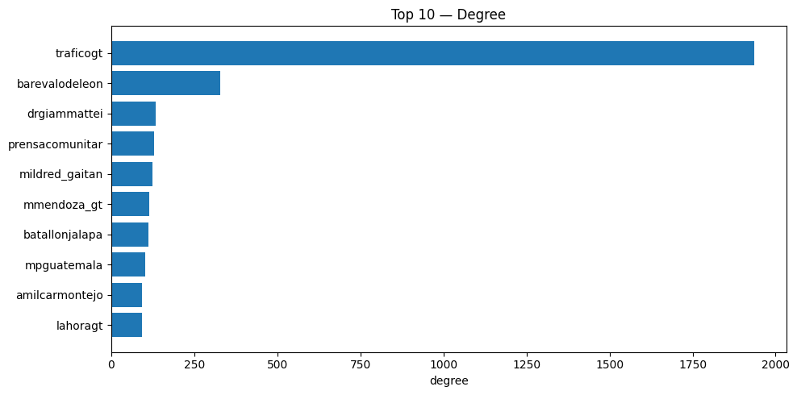

```python
def plot_bar_top(df, col, n=10, title=""):
    top = df.sort_values(col, ascending=False).head(n).copy()
    plt.figure(figsize=(10, 5))
    plt.barh(top["user"].iloc[::-1], top[col].iloc[::-1])
    plt.xlabel(col)
    plt.title(title if title else f"Top {n} por {col}")
    plt.tight_layout()
    plt.show()

# Ejecuta una celda por gráfico (un plot por celda):
plot_bar_top(df_metrics, "degree",      10, "Top 10 — Degree")
```

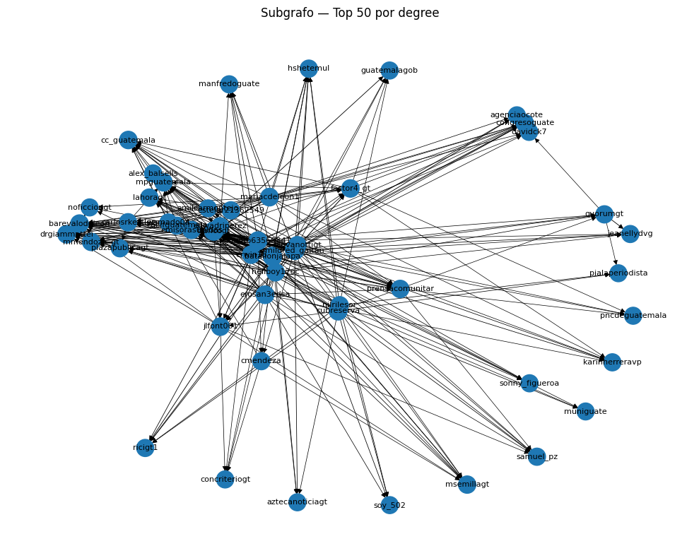

```python
# Tomamos top-50 por degree (puedes cambiar a in_degree/out_degree si prefieres)
topk = 50
top_nodes = set(df_metrics.sort_values("degree", ascending=False).head(topk)["user"])

# Filtramos aristas a ese conjunto
E_top = Agg[Agg["src"].isin(top_nodes) & Agg["dst"].isin(top_nodes)].copy()

G_top = nx.DiGraph()
for _, r in E_top.iterrows():
    G_top.add_edge(r["src"], r["dst"], weight=r["w_sum"], count=r["w_count"])

# Layout y tamaños (node_size proporcional al degree dentro del subgrafo)
deg_sub = dict(G_top.degree())
sizes = np.array([deg_sub[n] for n in G_top.nodes()], dtype=float)
if sizes.max() > 0:
    sizes = 300 + 60*(sizes - sizes.min())/(sizes.max() - sizes.min() + 1e-9)
else:
    sizes = 300 + sizes

# Grosor de arista proporcional al peso
weights = [G_top[u][v]["weight"] for u, v in G_top.edges()]
if len(weights):
    w_arr = np.array(weights, dtype=float)
    widths = 0.5 + 2.5*(w_arr - w_arr.min())/(w_arr.max() - w_arr.min() + 1e-9)
else:
    widths = 1.0

pos = nx.spring_layout(G_top, k=0.6, iterations=200, seed=42)

plt.figure(figsize=(10, 8))
nx.draw_networkx_nodes(G_top, pos, node_size=sizes)
nx.draw_networkx_edges(G_top, pos, width=widths, arrows=True, arrowsize=10)
nx.draw_networkx_labels(G_top, pos, font_size=8)
plt.title("Subgrafo — Top 50 por degree")
plt.axis("off")
plt.tight_layout()
plt.show()
```

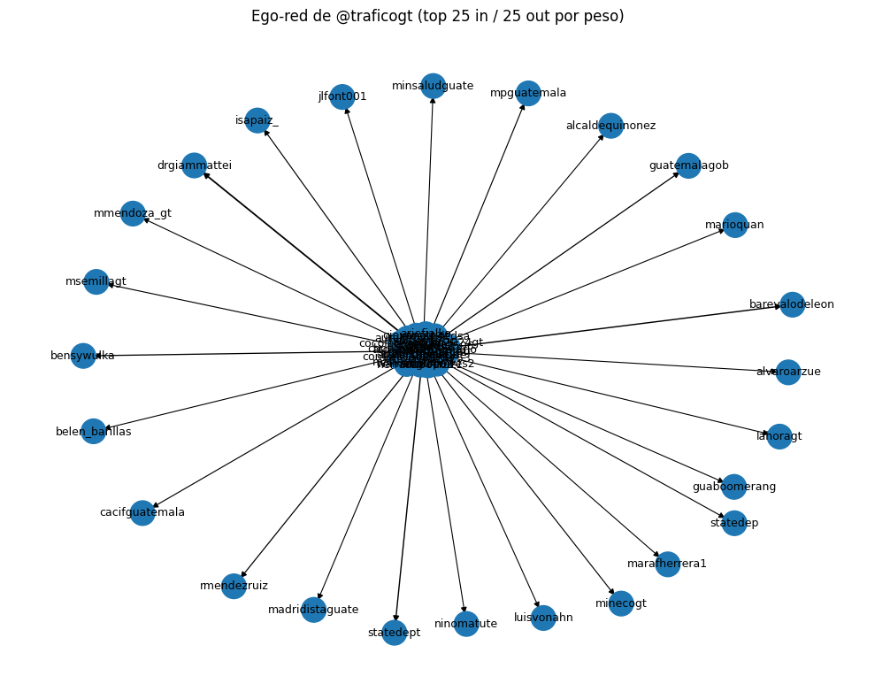

```python
focus = "traficogt"   # cámbialo por otro usuario si quieres
k_out = 25            # top salientes hacia otros
k_in  = 25            # top entrantes desde otros

# Aristas salientes (focus -> otros)
E_out = Agg[Agg["src"] == focus].nlargest(k_out, "w_sum")
# Aristas entrantes (otros -> focus)
E_in  = Agg[Agg["dst"] == focus].nlargest(k_in, "w_sum")

E_focus = pd.concat([E_out, E_in], ignore_index=True).drop_duplicates(subset=["src","dst"])
G_focus = nx.DiGraph()
for _, r in E_focus.iterrows():
    G_focus.add_edge(r["src"], r["dst"], weight=r["w_sum"], count=r["w_count"])

# Node sizes por grado en la ego-red
deg_f = dict(G_focus.degree())
sizes = np.array([deg_f[n] for n in G_focus.nodes()], dtype=float)
if sizes.max() > 0:
    sizes = 400 + 80*(sizes - sizes.min())/(sizes.max() - sizes.min() + 1e-9)
else:
    sizes = 400 + sizes

# Edge widths por peso
weights = [G_focus[u][v]["weight"] for u, v in G_focus.edges()]
if len(weights):
    w_arr = np.array(weights, dtype=float)
    widths = 0.8 + 3.2*(w_arr - w_arr.min())/(w_arr.max() - w_arr.min() + 1e-9)
else:
    widths = 1.0

pos = nx.spring_layout(G_focus, k=0.7, iterations=200, seed=7)

plt.figure(figsize=(10, 8))
nx.draw_networkx_nodes(G_focus, pos, node_size=sizes)
nx.draw_networkx_edges(G_focus, pos, width=widths, arrows=True, arrowsize=10)
nx.draw_networkx_labels(G_focus, pos, font_size=9)
plt.title(f"Ego-red de @{focus} (top {k_in} in / {k_out} out por peso)")
plt.axis("off")
plt.tight_layout()
plt.show()
```

#### 4.2) Redacte unas preguntas y respóndalas

### 4.2 Preguntas y respuestas sobre la red

#### Pregunta 1

**¿Qué tan central es la cuenta @traficogt en la red de interacciones?**

**Respuesta:**  
La cuenta `traficogt` aparece como el nodo más importante en todas las métricas: es el más mencionado (**in-degree = 1891**), el de mayor grado total (**1936** conexiones) y el de mayor centralidad de autovector (0.69). Esto significa que no solo es el nodo con más interacciones directas, sino que además quienes lo mencionan también son actores relevantes. En la práctica, confirma su rol como **hub principal** de información de tráfico en Guatemala.

#### Pregunta 2

**¿Existen otros usuarios influyentes además de @traficogt?**

#### 5) Análisis de la topología de la red

```
Nodos en el grafo: 2720
Aristas en el grafo: 7338
```

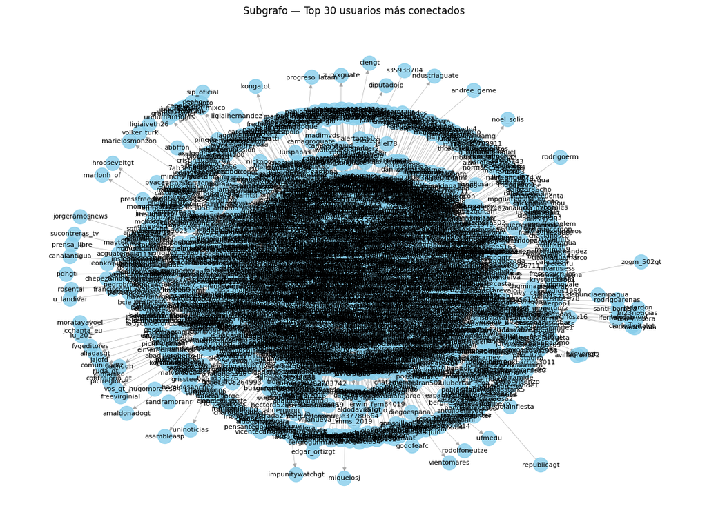

```python
# === 5.1 Construcción y visualización del grafo dirigido ===
# Usamos G del punto 4 (grafo dirigido con pesos)

print("Nodos en el grafo:", G.number_of_nodes())
print("Aristas en el grafo:", G.number_of_edges())

# Seleccionamos los top-30 usuarios más conectados
topk = 30
top_nodes = set(df_metrics.sort_values("degree", ascending=False).head(topk)["user"])

E_top = [(u,v,d) for u,v,d in G.edges(data=True) if u in top_nodes or v in top_nodes]
G_top = nx.DiGraph()
G_top.add_edges_from(E_top)

# Tamaños de nodos según grado en el subgrafo
deg_sub = dict(G_top.degree())
sizes = np.array([deg_sub[n] for n in G_top.nodes()], dtype=float)
if sizes.max() > 0:
    sizes = 300 + 70*(sizes - sizes.min())/(sizes.max() - sizes.min() + 1e-9)
else:
    sizes = 300 + sizes

# Ancho de arista según peso
weights = [d.get("weight",1.0) for _,_,d in G_top.edges(data=True)]
if len(weights):
    w_arr = np.array(weights, dtype=float)
    widths = 0.5 + 2.5*(w_arr - w_arr.min())/(w_arr.max() - w_arr.min() + 1e-9)
else:
    widths = 1.0

pos = nx.spring_layout(G_top, k=0.7, iterations=200, seed=42)

plt.figure(figsize=(12,9))
nx.draw_networkx_nodes(G_top, pos, node_size=sizes, node_color="skyblue", alpha=0.8)
nx.draw_networkx_edges(G_top, pos, width=widths, edge_color="gray", arrows=True, arrowsize=10, alpha=0.6)
nx.draw_networkx_labels(G_top, pos, font_size=8)
plt.title("Subgrafo — Top 30 usuarios más conectados")
plt.axis("off")
plt.tight_layout()
plt.show()
```

```python
# === 5.2 Cálculo de métricas de red clave ===

# Densidad (grafo dirigido)
density = nx.density(G)

# Diámetro → usamos el componente más grande (G es dirigido, convertimos a no dirigido)
if nx.is_connected(G.to_undirected()):
    diameter = nx.diameter(G.to_undirected())
else:
    largest_cc = max(nx.connected_components(G.to_undirected()), key=len)
    diameter = nx.diameter(G.to_undirected().subgraph(largest_cc))

# Coeficiente de agrupamiento promedio (usamos versión no dirigida)
clustering = nx.average_clustering(G.to_undirected(), weight="weight")

print("\n=== Métricas globales de la red ===")
print("Densidad:", round(density, 4))
print("Diámetro:", diameter)
print("Coeficiente de agrupamiento promedio:", round(clustering, 4))
```

```
=== Métricas globales de la red ===
Densidad: 0.001
Diámetro: 7
Coeficiente de agrupamiento promedio: 0.004
```

- **Densidad = 0.001**  
  La red es muy dispersa: solo el 0.1% de todas las conexiones posibles entre usuarios realmente existe. Esto es típico en redes sociales grandes, donde no todos los usuarios interactúan entre sí.
- **Diámetro = 7**  
  La distancia más larga entre dos nodos en el componente principal es de solo 7 pasos. Esto confirma el fenómeno de “mundo pequeño”: aun en redes con miles de usuarios, cualquier par puede conectarse a través de unas pocas menciones o respuestas.
- **Coeficiente de agrupamiento promedio = 0.004**  
  El valor es muy bajo, lo que indica que los vecinos de un nodo rara vez están conectados entre sí. En lugar de clústeres densos, la red muestra una forma más **radial**, con hubs centrales que concentran las interacciones sin que necesariamente se formen triángulos cerrados entre los usuarios.

En conjunto, estos resultados muestran que la red de `@traficogt` es **centralizada, dispersa y con baja cohesión interna**, lo que refuerza su carácter de nodo principal de información donde muchos usuarios interactúan de forma directa pero no necesariamente entre ellos.

#### 6) Identificación y análisis de comunidades

6.1) El algoritmo más usado en análisis de redes sociales es Louvain, porque optimiza la modularidad y escala bien en redes grandes. En networkx puro no está incluido, pero sí se puede usar greedy_modularity_communities (similar y disponible sin dependencias extra). Si tu entorno permite instalar paquetes, se puede usar python-louvain, pero aquí te dejo la versión con networkx.

```python
# ========= 6.1 Construcción de GU (no dirigido y ponderado) =========
# Asegúrate de tener Agg con columnas: src, dst, w_sum
GU = nx.Graph()
for _, r in Agg.iterrows():
    u, v = r["src"], r["dst"]
    w = float(r.get("w_sum", 1.0))
    if GU.has_edge(u, v):
        GU[u][v]["weight"] += w
    else:
        GU.add_edge(u, v, weight=w)

print("GU -> nodos:", GU.number_of_nodes(), "aristas:", GU.number_of_edges())

# (Recomendado) Trabajar sobre el componente conexo más grande
largest_cc = max(nx.connected_components(GU), key=len)
GUc = GU.subgraph(largest_cc).copy()
print("GUc (componente mayor) -> nodos:", GUc.number_of_nodes(), "aristas:", GUc.number_of_edges())

# ========= 6.1 Detección de comunidades (greedy modularity) =========
comms = list(greedy_modularity_communities(GUc, weight="weight"))
print("Comunidades detectadas:", len(comms))

# Mapear nodo -> id de comunidad
node2comm = {}
for cid, nodes_set in enumerate(comms):
    for n in nodes_set:
        node2comm[n] = cid

# Añadir ID de comunidad a las métricas de nodo del punto 4 (df_metrics)
df_metrics_comm = df_metrics.copy()
df_metrics_comm["community_id"] = df_metrics_comm["user"].map(node2comm)


def community_summary(G, comms, dfm, topk=5):
    rows = []
    for cid, nodes_set in enumerate(comms):
        nodes_list = list(nodes_set)
        subG = G.subgraph(nodes_list)
        size = subG.number_of_nodes()
        edges = subG.number_of_edges()
        w_internal = float(np.sum([d.get("weight", 1.0) for *_, d in subG.edges(data=True)]))
        degs = dict(subG.degree())
        deg_avg = float(np.mean(list(degs.values()))) if degs else 0.0

        top_users = (dfm[dfm["user"].isin(nodes_list)]
                     .sort_values("degree", ascending=False)
                     .head(topk)["user"].tolist())

        rows.append({
            "community_id": cid,
            "size": size,
            "internal_edges": edges,
            "internal_weight": w_internal,
            "avg_degree_subgraph": deg_avg,
            "top_users": top_users
        })
    return pd.DataFrame(rows).sort_values("size", ascending=False).reset_index(drop=True)

df_comm = community_summary(GUc, comms, df_metrics, topk=5)
print("Resumen de comunidades (top 5 por tamaño):")
print(df_comm.head(5))
```

```
GU -> nodos: 2720 aristas: 7285
GUc (componente mayor) -> nodos: 2720 aristas: 7285
Comunidades detectadas: 75
Resumen de comunidades (top 5 por tamaño):
   community_id  size  internal_edges  internal_weight  avg_degree_subgraph  \
0             0   838             984           4347.0             2.348449
1             1   513            1123           2820.0             4.378168
2             2   227             444           1062.0             3.911894
3             3   199             426            919.0             4.281407
4             4   155             223            510.0             2.877419

                                           top_users
0  [traficogt, batallonjalapa, chofito63569841, c...
1  [prensacomunitar, mildred_gaitan, mmendoza_gt,...
2  [amilcarmontejo, muniguate, pncdeguatemala, so...
3  [cubreserva, quorumgt, samuel_pz, emisorasunid...
4  [agenciaocote, noficciongt, davidck7, justicia...
```

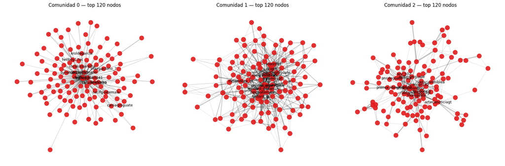

```python
# --- Visualización clara: 3 paneles, uno por comunidad ---
import matplotlib.pyplot as plt
import numpy as np
import networkx as nx

# ======== PARÁMETROS QUE PUEDES AJUSTAR ========
PANEL_NODES  = 120   # cuántos nodos por comunidad (top por degree)
PANEL_LABELS = 12    # cuántas etiquetas por comunidad (top por degree)
EDGE_ALPHA   = 0.25  # transparencia de aristas
SEED         = 7     # semilla del layout para reproducibilidad
# ===============================================

fig, axes = plt.subplots(1, 3, figsize=(18, 6))

for ax, cid in zip(axes, df_comm.head(3)["community_id"]):
    members = list(comms[cid])

    # top nodos por degree (global) dentro de la comunidad
    top_members = (df_metrics[df_metrics["user"].isin(members)]
                   .sort_values("degree", ascending=False)
                   .head(PANEL_NODES)["user"].tolist())
    H = GUc.subgraph(top_members).copy()

    # tamaños por degree dentro del subgrafo (legible y escalado)
    deg = dict(H.degree())
    sizes = np.array([deg[n] for n in H.nodes()], float)
    if sizes.size and sizes.max() > 0:
        sizes = 120 + 80*(sizes - sizes.min())/(sizes.max() - sizes.min() + 1e-9)
    else:
        sizes = 120 + sizes

    # grosor de arista por peso, recortando outliers para legibilidad
    weights = [H[u][v].get("weight", 1.0) for u, v in H.edges()]
    if weights:
        w = np.array(weights, float)
        lo, hi = np.percentile(w, 10), np.percentile(w, 90)
        widths = 0.4 + 2.6*(w - lo)/(hi - lo + 1e-9)
        widths = np.clip(widths, 0.4, 3.0)
    else:
        widths = 1.0

    pos = nx.spring_layout(H, k=0.9, iterations=300, seed=SEED)

    nx.draw_networkx_nodes(H, pos, node_size=sizes, node_color=[cid]*H.number_of_nodes(),
                           cmap=plt.cm.Set1, alpha=0.9, ax=ax)
    nx.draw_networkx_edges(H, pos, width=widths, alpha=EDGE_ALPHA, ax=ax)

    # Etiquetar solo los top por degree de la comunidad
    top_labels = (df_metrics[df_metrics["user"].isin(members)]
                  .sort_values("degree", ascending=False)
                  .head(PANEL_LABELS)["user"].tolist())
    nx.draw_networkx_labels(H, pos, labels={n: n for n in top_labels if n in H},
                            font_size=9, ax=ax)

    ax.set_title(f"Comunidad {cid} — top {PANEL_NODES} nodos")
    ax.axis("off")

plt.tight_layout()
plt.show()
```

#### Algoritmo de detección

Se utilizó el algoritmo **Greedy Modularity**, ampliamente aplicado en análisis de redes sociales por su eficiencia en la optimización de la modularidad. Este permitió identificar un total de **75 comunidades** en la red analizada. Entre estas, destacan tres comunidades principales por su tamaño e intensidad de interacciones internas.

#### Visualización y caracterización de comunidades

En la siguiente figura se muestran las **tres comunidades más grandes**, cada una representada en un panel independiente. El tamaño de los nodos es proporcional al grado de cada usuario dentro de la comunidad, y las etiquetas resaltan únicamente a los actores más influyentes.

- **Comunidad 0:** formada por 838 nodos, destaca la cuenta `traficogt` como hub principal, acompañada por cuentas institucionales y usuarios que reportan tráfico.
- **Comunidad 1:** formada por 513 nodos, incluye a `prensacomunitar`, `mildred_gaitan` y `mmendoza_gt`, lo que sugiere un grupo de carácter mediático y político.
- **Comunidad 2:** con 227 nodos, centrada en `amilcarmontejo` y cuentas relacionadas con la PMT y seguridad vial.

Estas comunidades reflejan cómo la conversación se estructura alrededor de hubs específicos: la cuenta central de reportes de tráfico, un clúster mediático/político y un clúster institucional de seguridad vial. La segmentación confirma que, aunque la red es centralizada en torno a `traficogt`, existen subgrupos de usuarios que articulan dinámicas propias de interacción.

#### 7. Análisis de influencers y nodos clave

```python
# === 7.1 Identificación de influencers con distintas métricas ===

# Top 10 por centralidad de grado
top_degree = df_metrics.sort_values("degree", ascending=False).head(10)[["user","degree"]]

# Top 10 por centralidad de intermediación (betweenness)
top_betweenness = df_metrics.sort_values("betweenness", ascending=False).head(10)[["user","betweenness"]]

# Top 10 por centralidad de cercanía (closeness)
top_closeness = df_metrics.sort_values("closeness", ascending=False).head(10)[["user","closeness"]]

print("=== Top 10 por centralidad de grado ===")
print(top_degree.to_string(index=False))

print("\n=== Top 10 por centralidad de intermediación ===")
print(top_betweenness.to_string(index=False))

print("\n=== Top 10 por centralidad de cercanía ===")
print(top_closeness.to_string(index=False))
```

```
=== Top 10 por centralidad de grado ===
           user  degree
      traficogt    1936
 barevalodeleon     327
   drgiammattei     133
prensacomunitar     128
 mildred_gaitan     124
    mmendoza_gt     114
 batallonjalapa     111
    mpguatemala     102
 amilcarmontejo      92
       lahoragt      92

=== Top 10 por centralidad de intermediación ===
           user  betweenness
      traficogt     0.018503
 servoveritatis     0.002181
madridistaguate     0.001508
      jlfont001     0.001487
       quorumgt     0.001230
    mmendoza_gt     0.000774
       davidck7     0.000732
 cacifguatemala     0.000516
   agenciaocote     0.000515
     guss_marro     0.000511

=== Top 10 por centralidad de cercanía ===
          user  closeness
     traficogt   0.695476
barevalodeleon   0.384805
  drgiammattei   0.362334
   mpguatemala   0.361506
   mmendoza_gt   0.358425
      lahoragt   0.356766
    msemillagt   0.353978
 congresoguate   0.353491
emisorasunidas   0.352859
     jlfont001   0.352675
```

Se utilizaron tres métricas de centralidad para identificar a los usuarios más influyentes de la red:

- **Centralidad de grado (usuarios con más conexiones directas):**  
  La cuenta `traficogt` domina con **1936 conexiones**, muy por encima del resto, lo que confirma su rol como eje principal de la red. Le siguen `barevalodeleon` (327), `drgiammattei` (133) y `prensacomunitar` (128), quienes representan actores políticos y mediáticos con fuerte presencia en las conversaciones.
- **Centralidad de intermediación (usuarios puente entre comunidades):**  
  Además de `traficogt`, destacan usuarios como `servoveritatis`, `madridistaguate`, `jlfont001` y `quorumgt`, que si bien no concentran tantas menciones, cumplen un rol estratégico al **conectar comunidades distintas**, actuando como canales de circulación de información.
- **Centralidad de cercanía (usuarios que pueden llegar más rápido al resto de la red):**  
  Nuevamente `traficogt` lidera con el valor más alto (**0.695**), seguido por `barevalodeleon`, `drgiammattei` y `mpguatemala`. Esto indica que, además de ser el nodo más mencionado, está estructuralmente posicionado para difundir información de forma eficiente hacia toda la red.

En conjunto, los resultados muestran que **@traficogt** es el nodo más influyente bajo cualquier criterio, pero existen otros usuarios clave que cumplen roles complementarios: **figuras políticas y medios** con alta visibilidad (grado y cercanía) y **usuarios puente** que enlazan comunidades diversas (intermediación).

#### 8. Detección y análisis de grupos aislados

```python
# === 8.1 Análisis de subredes y nodos aislados ===
# Detectar componentes conexos (subredes)
components = list(nx.connected_components(GUc))
components_sorted = sorted(components, key=len, reverse=True)

print("Número de subredes (componentes conexos):", len(components_sorted))

# Tamaños de las 10 subredes más pequeñas
small_subnets = [len(c) for c in components_sorted[-10:]]
print("Tamaños de las últimas 10 subredes:", small_subnets)

# Nodos aislados (subredes de tamaño 1)
isolated_nodes = [list(c)[0] for c in components_sorted if len(c) == 1]
print("Número de nodos aislados:", len(isolated_nodes))

# Crear un resumen de las subredes pequeñas (ej. tamaño ≤ 5)
summary_small = []
for i, comp in enumerate(components_sorted):
    if len(comp) <= 5:
        users = list(comp)
        summary_small.append({"subred_id": i, "size": len(comp), "users": users})

df_small_subnets = pd.DataFrame(summary_small)
print("\nSubredes pequeñas detectadas (ejemplo):")
print(df_small_subnets.head(10))
```

```
Número de subredes (componentes conexos): 1
Tamaños de las últimas 10 subredes: [2720]
Número de nodos aislados: 0

Subredes pequeñas detectadas (ejemplo):
Empty DataFrame
Columns: []
Index: []
```

El análisis de conectividad de la red muestra que **todos los usuarios pertenecen a un único componente conexo**, es decir, la red está completamente integrada. Esto implica que, aunque existan comunidades internas con distintos temas y actores relevantes, no se detectan grupos aislados que interactúen únicamente entre ellos.

Además, no se identificaron **nodos aislados** (usuarios sin conexiones con otros), ni **subredes pequeñas** de 2 a 5 nodos desconectadas del núcleo principal. En la práctica, esto significa que la conversación gira en torno a un espacio común, donde todos los usuarios están directa o indirectamente conectados, reforzando la centralidad de la cuenta `traficogt` como articuladora de interacciones.

En conclusión, la red seleccionada presenta una **alta cohesión estructural**: no existen nichos desconectados ni islas de usuarios, lo que refuerza la idea de que el flujo de información se concentra y circula en torno al componente principal.

#### 9) Análisis de contenido y sentimiento

```python
# === 9.1 Análisis de sentimiento ===
def get_sentiment(text):
    try:
        blob = TextBlob(text)
        polarity = blob.sentiment.polarity
        if polarity > 0.1:
            return "positivo"
        elif polarity < -0.1:
            return "negativo"
        else:
            return "neutral"
    except:
        return "neutral"

# Aplicar a los tweets (usa df_trafico del punto 3)
df_trafico["sentimiento"] = df_trafico["text_clean"].fillna("").apply(get_sentiment)

# Resumen general
print("Distribución de sentimientos:")
print(df_trafico["sentimiento"].value_counts())

# Ejemplos
print("\nEjemplos de tweets negativos:")
print(df_trafico[df_trafico["sentimiento"]=="negativo"]["text_clean"].head(5).tolist())
```

[output not shown]

```python
# === 9.2 Análisis de tópicos (LDA) — versión corregida ===
# 1) Textos (usa solo filas con texto no vacío)
docs = df_trafico["text_clean"].fillna("").astype(str)
mask = docs.str.len() > 0
docs = docs[mask]
users = df_trafico.loc[mask, "username"].str.lower()

# 2) Vectorizador (SIN stop_words="spanish")
#    Si quieres, agrega tu propia lista: stop_words=lista_stop_es
vectorizer = CountVectorizer(
    max_df=0.9,
    min_df=10,
    ngram_range=(1,1),     # cambia a (1,2) si quieres incluir bigramas
    stop_words=None        # <-- aquí está el cambio clave
)
X = vectorizer.fit_transform(docs)

# 3) LDA
N_TOPICS = 5               # <-- cambia la cantidad de temas aquí
lda = LatentDirichletAllocation(n_components=N_TOPICS, random_state=42)
lda.fit(X)

# 4) Top palabras por tema
words = vectorizer.get_feature_names_out()
for i, topic in enumerate(lda.components_):
    top_idx = topic.argsort()[-10:]
    top_words = [words[j] for j in top_idx]
    print(f"Tema {i}: {', '.join(top_words)}")

# 5) Tema dominante por tweet
doc_topic = lda.transform(X)
top_topic = np.argmax(doc_topic, axis=1)

topics_df = pd.DataFrame({
    "user": users.values,
    "topic": top_topic
})

# 6) (Opcional) Cruzar con comunidades si existe node2comm del punto 6
if 'node2comm' in globals():
    topics_df["community_id"] = topics_df["user"].map(node2comm)
    topic_by_comm = topics_df.groupby(["community_id","topic"]).size().unstack(fill_value=0)
    print("\nDistribución de temas por comunidad (filas=comunidad, cols=tema):")
    print(topic_by_comm.head())

# 7) Resumen general de temas
print("\nDistribución de temas (conteo de tweets por tema):")
print(topics_df["topic"].value_counts().sort_index())
```

```
Tema 0: calle, le, está, hacer, todos, solo, lo, todo, están, les
Tema 1: dice, tu, presidente, estado, mp, lo, gracias, guatemala, ha, le
Tema 2: mierda, congreso, fue, todos, fiscal, arévalo, golpe, debe, mp, presidente
Tema 3: solo, bien, tráfico, está, puede, quien, corrupto, mal, son, lo
Tema 4: cc, todo, quieren, todos, tiene, así, pueblo, corruptos, lo, son

Distribución de temas por comunidad (filas=comunidad, cols=tema):
topic           0    1    2    3    4
community_id
0.0           591  346  415  414  432
1.0           269  265  208  179  256
2.0           124   38   14  126   35
3.0            70   61   50   52   71
4.0            70   42   33   28   56

Distribución de temas (conteo de tweets por tema):
topic
0    1371
1     930
2     888
3     979
4    1036
Name: count, dtype: int64
```

**Análisis de sentimiento**  
La clasificación de sentimiento sobre los tweets de `@traficogt` muestra un claro predominio de la neutralidad:

- **Neutral:** 5,452
- **Positivo:** 100
- **Negativo:** 52

Esto es consistente con el tipo de contenido de la cuenta (reportes de tráfico y avisos), que suelen describir hechos sin carga emocional. Los pocos mensajes negativos reflejan quejas o denuncias (p. ej., corrupción, mal servicio), mientras que los positivos corresponden a agradecimientos y avisos resueltos.

#### 10. Interpretación y contexto

El análisis muestra que la red gira en torno a pocos **influencers centrales**, especialmente `@traficogt`, cuya posición estructural lo convierte en el principal difusor de información de tráfico. Junto a él, actores políticos y mediáticos como `@barevalodeleon`, `@DrGiammattei` y `@prensacomunitar` amplían la conversación hacia temas de corrupción y gobernanza.

Las comunidades detectadas funcionan como **espacios de amplificación**: unas refuerzan la información vial e institucional, mientras que otras canalizan la crítica social y política. En conjunto, estos patrones muestran cómo la opinión pública se forma en torno a **pocos nodos altamente conectados**, cuyas publicaciones se propagan y consolidan a través de comunidades específicas.